# Project No. 2 Introduction into Data Science

# Problem-Set 2

Problem-Set No.2 Wrangeling Subway-Data: Exercise 1

```python
#Problem-Set 2 Wrangeling Subway-Data: 1:
'''
    This function should run a SQL query on a dataframe of
    weather data.  The SQL query should return one column and
    one row - a count of the number of days in the dataframe where
    the rain column is equal to 1 (i.e., the number of days it
    rained).  The dataframe will be titled 'weather_data'. You'll
    need to provide the SQL query.  You might find SQL's count function
    useful for this exercise.  You can read more about it here:

    https://dev.mysql.com/doc/refman/5.1/en/counting-rows.html

    You might also find that interpreting numbers as integers or floats may not
    work initially.  In order to get around this issue, it may be useful to cast
    these numbers as integers.  This can be done by writing cast(column as integer).
    So for example, if we wanted to cast the maxtempi column as an integer, we would actually
    write something like where cast(maxtempi as integer) = 76, as opposed to simply
    where maxtempi = 76.

    You can see the weather data that we are passing in below:
    https://www.dropbox.com/s/7sf0yqc9ykpq3w8/weather_underground.csv
'''

import csv
import pandas
from pandasql import sqldf
pandas.options.mode.chained_assignment = None

def num_rainy_days(filename):
    weather_data = pandas.read_csv(filename,encoding="utf-8")
    weather_data_1 = weather_data[['Hour', 'ENTRIESn_hourly','rain']]

    #print sqldf("SELECT * FROM weather_data_1 LIMIT 10;",locals()).head()


    q = """
        SELECT
        rain,count(rain)

        FROM weather_data_1

        WHERE
        rain>0;
        """

    q_2 = """
        SELECT
        rain,count(rain)

        FROM weather_data_1

        WHERE
        rain==0;
        """

    #Execute your SQL command against the pandas frame
    print '\033[5m' + "Number of rainy_days:"
    print sqldf(q,locals())
    print '\033[5m' + "Number of Days without Rain:"
    print sqldf(q_2,locals())


# Use the function above
num_rainy_days('turnstile_data_master_with_weather.csv')
```

```
Number of rainy_days:
   rain  count(rain)
0     1        44104
Number of Days without Rain:
   rain  count(rain)
0     0        87847
```

Problem-Set No.2 Wrangeling Subway-Data: Exercise 2

```python
'''
    This function should run a SQL query on a dataframe of
    weather data.  The SQL query should return two columns and
    two rows - whether it was foggy or not (0 or 1) and the max
    maxtempi for that fog value (i.e., the maximum max temperature
    for both foggy and non-foggy days).  The dataframe will be
    titled 'weather_data'. You'll need to provide the SQL query.

    You might also find that interpreting numbers as integers or floats may not
    work initially.  In order to get around this issue, it may be useful to cast
    these numbers as integers.  This can be done by writing cast(column as integer).
    So for example, if we wanted to cast the maxtempi column as an integer, we would actually
    write something like where cast(maxtempi as integer) = 76, as opposed to simply
    where maxtempi = 76.

    You can see the weather data that we are passing in below:
    https://www.dropbox.com/s/7sf0yqc9ykpq3w8/weather_underground.csv
'''
import pandas
import pandasql


def max_temp_aggregate_by_fog(filename):

    weather_data = pandas.read_csv(filename,encoding="utf-8")
    weather_data_1 = weather_data[['Hour', 'ENTRIESn_hourly','fog','maxtempi']]

    q = """
        SELECT
        fog,maxtempi

        FROM weather_data_1

        Group by fog;
        """
        #Execute your SQL command against the pandas frame
    print '\033[5m' + "Max Maxtempi value for the fog day and non-foggy days:"
    print sqldf(q,locals())

# Use the function above
max_temp_aggregate_by_fog('turnstile_data_master_with_weather.csv')
```

```
Max Maxtempi value for the fog day and non-foggy days:
   fog  maxtempi
0    0        86
1    1        81
```

Problem-Set No.2 Wrangeling Subway-Data: Exercise 3

```python
'''
    This function should run a SQL query on a dataframe of
    weather data.  The SQL query should return one column and
    one row - the average meantempi on days that are a Saturday
    or Sunday (i.e., the the average mean temperature on weekends).
    The dataframe will be titled 'weather_data' and you can access
    the date in the dataframe via the 'date' column.

    You'll need to provide  the SQL query.

    You might also find that interpreting numbers as integers or floats may not
    work initially.  In order to get around this issue, it may be useful to cast
    these numbers as integers.  This can be done by writing cast(column as integer).
    So for example, if we wanted to cast the maxtempi column as an integer, we would actually
    write something like where cast(maxtempi as integer) = 76, as opposed to simply
    where maxtempi = 76.

    Also, you can convert dates to days of the week via the 'strftime' keyword in SQL.
    For example, cast (strftime('%w', date) as integer) will return 0 if the date
    is a Sunday or 6 if the date is a Saturday.
'''
import pandas
import pandasql

def avg_weekend_temperature(filename):

    weather_data = pandas.read_csv(filename,encoding="utf-8")
    weather_data_1 = weather_data[['DATEn','meantempi']]

    q = """
       SELECT
        avg(meantempi)
        from
        weather_data_1
        WHERE
        cast (strftime('%w', DATEn) as integer)=0  or  cast (strftime('%w', DATEn) as integer)=6;
    """
    #Execute your SQL command against the pandas frame
    print '\033[5m' + "Average meantempi value:"
    print sqldf(q,locals())

avg_weekend_temperature('turnstile_data_master_with_weather.csv')
```

```
Average meantempi value:
   avg(meantempi)
0       65.100667
```

Problem-Set No.2 Wrangeling Subway-Data: Exercise 4

```python
'''
    This function should run a SQL query on a dataframe of
    weather data. More specifically you want to find the average
    minimum temperature (mintempi column of the weather dataframe) on
    rainy days where the minimum temperature is greater than 55 degrees.

    You might also find that interpreting numbers as integers or floats may not
    work initially.  In order to get around this issue, it may be useful to cast
    these numbers as integers.  This can be done by writing cast(column as integer).
    So for example, if we wanted to cast the maxtempi column as an integer, we would actually
    write something like where cast(maxtempi as integer) = 76, as opposed to simply
    where maxtempi = 76.
'''

import pandas
import pandasql

def avg_min_temperature(filename):
    weather_data = pandas.read_csv(filename,encoding="utf-8")
    weather_data_1 = weather_data[['DATEn','meantempi','mintempi','rain']]

    q = """
        SELECT
        avg(cast(mintempi as integer))
        from
        weather_data_1
        WHERE
        rain == 1 AND mintempi>55
    """
    #Execute your SQL command against the pandas frame
    print '\033[5m' + "Average mintempi value on rainy days where the mintempi is greater than 55 degrees:"
    print sqldf(q,locals())

avg_min_temperature('turnstile_data_master_with_weather.csv')
```

```
Average mintempi value on rainy days where the mintempi is greater than 55 degrees:
   avg(cast(mintempi as integer))
0                        61.23886
```

Problem-Set No.2 Wrangeling Subway-Data: Exercise 5

```python
'''
    Filenames is a list of MTA Subway turnstile text files. A link to an example
    MTA Subway turnstile text file can be seen at the URL below:
    http://web.mta.info/developers/data/nyct/turnstile/turnstile_110507.txt

    As you can see, there are numerous data points included in each row of the
    a MTA Subway turnstile text file.

    You want to write a function that will update each row in the text
    file so there is only one entry per row. A few examples below:
    A002,R051,02-00-00,05-28-11,00:00:00,REGULAR,003178521,001100739
    A002,R051,02-00-00,05-28-11,04:00:00,REGULAR,003178541,001100746
    A002,R051,02-00-00,05-28-11,08:00:00,REGULAR,003178559,001100775

    Write the updates to a different text file in the format of "updated_" + filename.
    For example:
        1) if you read in a text file called "turnstile_110521.txt"
        2) you should write the updated data to "updated_turnstile_110521.txt"

    The order of the fields should be preserved. Remember to read through the
    Instructor Notes below for more details on the task.

    In addition, here is a CSV reader/writer introductory tutorial:
    http://goo.gl/HBbvyy

    You can see a sample of the turnstile text file that's passed into this function
    and the the corresponding updated file in the links below:
'''

import csv

def fix_turnstile_data(filenames):

     for name in filenames:
        print name
        print '\n'
        with open(name, 'r') as old_f:
            with open("updated_{0}".format(name), 'w') as new_f:
                print new_f
                writer=csv.writer(new_f)
                reader=csv.reader(old_f)
                l=list()

                for row in reader:
                    l=row[0:3]


                    increment=(len(row)-3)/5
                    #print len(row)
                    for i in range(3,len(row),5):
                        #print i
                        x=i+5
                        #print l
                        u=l+row[i:x]
                        #print u

                        writer.writerow(u)

# There is no solution because I had no array of filenames to read in,
# but these solution worked fine in the Udacity-Environment
```

Problem-Set No.2 Wrangeling Subway-Data: Exercise 6

```python
'''
    Write a function that takes the files in the list filenames, which all have the
    columns 'C/A, UNIT, SCP, DATEn, TIMEn, DESCn, ENTRIESn, EXITSn', and consolidates
    them into one file located at output_file.  There should be ONE row with the column
    headers, located at the top of the file. The input files do not have column header
    rows of their own.

    For example, if file_1 has:
    line 1 ...
    line 2 ...

    and another file, file_2 has:
    line 3 ...
    line 4 ...
    line 5 ...

    We need to combine file_1 and file_2 into a master_file like below:
     'C/A, UNIT, SCP, DATEn, TIMEn, DESCn, ENTRIESn, EXITSn'
    line 1 ...
    line 2 ...
    line 3 ...
    line 4 ...
    line 5 ...
'''
def create_master_turnstile_file(filenames, output_file):

        with open(output_file, 'w') as master_file:
            master_file.write('C/A,UNIT,SCP,DATEn,TIMEn,DESCn,ENTRIESn,EXITSn\n')
        for filename in filenames:
            with open(filename, 'r') as f:
                for row in f:
                    master_file.write(row)

# There is no solution because I had no array of filenames to read in,
# but these solution worked fine in the Udacity-Environment
```

Problem-Set No.2 Wrangeling Subway-Data: Exercise 7

```python
'''
    This function should read the csv file located at filename into a pandas dataframe,
    and filter the dataframe to only rows where the 'DESCn' column has the value 'REGULAR'.

    For example, if the pandas dataframe is as follows:
    ,C/A,UNIT,SCP,DATEn,TIMEn,DESCn,ENTRIESn,EXITSn
    0,A002,R051,02-00-00,05-01-11,00:00:00,REGULAR,3144312,1088151
    1,A002,R051,02-00-00,05-01-11,04:00:00,DOOR,3144335,1088159
    2,A002,R051,02-00-00,05-01-11,08:00:00,REGULAR,3144353,1088177
    3,A002,R051,02-00-00,05-01-11,12:00:00,DOOR,3144424,1088231

    The dataframe will look like below after filtering to only rows where DESCn column
    has the value 'REGULAR':
    0,A002,R051,02-00-00,05-01-11,00:00:00,REGULAR,3144312,1088151
    2,A002,R051,02-00-00,05-01-11,08:00:00,REGULAR,3144353,1088177
'''
import pandas
import csv

def filter_by_regular(filename):
    with open(filename,'r') as input_file:
        turnstile_data_0=pandas.DataFrame.from_csv(input_file,0,',',index_col = False)
        turnstile_data= turnstile_data_0[turnstile_data_0['DESCn']=='REGULAR']
        #print turnstile_data
    return turnstile_data
filter_by_regular('turnstile_data_master_with_weather.csv')
```

|  | Unnamed: 0 | UNIT | DATEn | TIMEn | Hour | DESCn | ENTRIESn_hourly | EXITSn_hourly | maxpressurei | maxdewpti | ... | meandewpti | meanpressurei | fog | rain | meanwindspdi | mintempi | meantempi | maxtempi | precipi | thunder |
| --- | --- | --- | --- | --- | --- | --- | --- | --- | --- | --- | --- | --- | --- | --- | --- | --- | --- | --- | --- | --- | --- |
| 0 | 0 | R001 | 2011-05-01 | 01:00:00 | 1 | REGULAR | 0 | 0 | 30.31 | 42 | ... | 39 | 30.27 | 0 | 0 | 5 | 50 | 60 | 69 | 0.00 | 0 |
| 1 | 1 | R001 | 2011-05-01 | 05:00:00 | 5 | REGULAR | 217 | 553 | 30.31 | 42 | ... | 39 | 30.27 | 0 | 0 | 5 | 50 | 60 | 69 | 0.00 | 0 |
| 2 | 2 | R001 | 2011-05-01 | 09:00:00 | 9 | REGULAR | 890 | 1262 | 30.31 | 42 | ... | 39 | 30.27 | 0 | 0 | 5 | 50 | 60 | 69 | 0.00 | 0 |
| 3 | 3 | R001 | 2011-05-01 | 13:00:00 | 13 | REGULAR | 2451 | 3708 | 30.31 | 42 | ... | 39 | 30.27 | 0 | 0 | 5 | 50 | 60 | 69 | 0.00 | 0 |
| 4 | 4 | R001 | 2011-05-01 | 17:00:00 | 17 | REGULAR | 4400 | 2501 | 30.31 | 42 | ... | 39 | 30.27 | 0 | 0 | 5 | 50 | 60 | 69 | 0.00 | 0 |
| 5 | 5 | R001 | 2011-05-01 | 21:00:00 | 21 | REGULAR | 3372 | 2122 | 30.31 | 42 | ... | 39 | 30.27 | 0 | 0 | 5 | 50 | 60 | 69 | 0.00 | 0 |
| 6 | 6 | R002 | 2011-05-01 | 01:00:00 | 1 | REGULAR | 0 | 0 | 30.31 | 42 | ... | 39 | 30.27 | 0 | 0 | 5 | 50 | 60 | 69 | 0.00 | 0 |
| 7 | 7 | R002 | 2011-05-01 | 05:00:00 | 5 | REGULAR | 42 | 66 | 30.31 | 42 | ... | 39 | 30.27 | 0 | 0 | 5 | 50 | 60 | 69 | 0.00 | 0 |
| 8 | 8 | R002 | 2011-05-01 | 09:00:00 | 9 | REGULAR | 50 | 125 | 30.31 | 42 | ... | 39 | 30.27 | 0 | 0 | 5 | 50 | 60 | 69 | 0.00 | 0 |
| 9 | 9 | R002 | 2011-05-01 | 13:00:00 | 13 | REGULAR | 316 | 716 | 30.31 | 42 | ... | 39 | 30.27 | 0 | 0 | 5 | 50 | 60 | 69 | 0.00 | 0 |
| 10 | 10 | R002 | 2011-05-01 | 17:00:00 | 17 | REGULAR | 633 | 968 | 30.31 | 42 | ... | 39 | 30.27 | 0 | 0 | 5 | 50 | 60 | 69 | 0.00 | 0 |
| 11 | 11 | R002 | 2011-05-01 | 21:00:00 | 21 | REGULAR | 639 | 566 | 30.31 | 42 | ... | 39 | 30.27 | 0 | 0 | 5 | 50 | 60 | 69 | 0.00 | 0 |
| 12 | 12 | R003 | 2011-05-01 | 00:00:00 | 0 | REGULAR | 0 | 0 | 30.31 | 42 | ... | 39 | 30.27 | 0 | 0 | 5 | 50 | 60 | 69 | 0.00 | 0 |
| 13 | 13 | R003 | 2011-05-01 | 04:00:00 | 4 | REGULAR | 0 | 0 | 30.31 | 42 | ... | 39 | 30.27 | 0 | 0 | 5 | 50 | 60 | 69 | 0.00 | 0 |
| 14 | 14 | R003 | 2011-05-01 | 12:00:00 | 12 | REGULAR | 0 | 0 | 30.31 | 42 | ... | 39 | 30.27 | 0 | 0 | 5 | 50 | 60 | 69 | 0.00 | 0 |
| 15 | 15 | R003 | 2011-05-01 | 16:00:00 | 16 | REGULAR | 0 | 0 | 30.31 | 42 | ... | 39 | 30.27 | 0 | 0 | 5 | 50 | 60 | 69 | 0.00 | 0 |
| 16 | 16 | R003 | 2011-05-01 | 20:00:00 | 20 | REGULAR | 0 | 0 | 30.31 | 42 | ... | 39 | 30.27 | 0 | 0 | 5 | 50 | 60 | 69 | 0.00 | 0 |
| 17 | 17 | R004 | 2011-05-01 | 00:00:00 | 0 | REGULAR | 0 | 0 | 30.31 | 42 | ... | 39 | 30.27 | 0 | 0 | 5 | 50 | 60 | 69 | 0.00 | 0 |
| 18 | 18 | R004 | 2011-05-01 | 04:00:00 | 4 | REGULAR | 0 | 0 | 30.31 | 42 | ... | 39 | 30.27 | 0 | 0 | 5 | 50 | 60 | 69 | 0.00 | 0 |
| 19 | 19 | R004 | 2011-05-01 | 08:00:00 | 8 | REGULAR | 0 | 0 | 30.31 | 42 | ... | 39 | 30.27 | 0 | 0 | 5 | 50 | 60 | 69 | 0.00 | 0 |
| 20 | 20 | R004 | 2011-05-01 | 12:00:00 | 12 | REGULAR | 0 | 0 | 30.31 | 42 | ... | 39 | 30.27 | 0 | 0 | 5 | 50 | 60 | 69 | 0.00 | 0 |
| 21 | 21 | R004 | 2011-05-01 | 16:00:00 | 16 | REGULAR | 0 | 0 | 30.31 | 42 | ... | 39 | 30.27 | 0 | 0 | 5 | 50 | 60 | 69 | 0.00 | 0 |
| 22 | 22 | R004 | 2011-05-01 | 20:00:00 | 20 | REGULAR | 0 | 0 | 30.31 | 42 | ... | 39 | 30.27 | 0 | 0 | 5 | 50 | 60 | 69 | 0.00 | 0 |
| 23 | 23 | R005 | 2011-05-01 | 00:00:00 | 0 | REGULAR | 0 | 0 | 30.31 | 42 | ... | 39 | 30.27 | 0 | 0 | 5 | 50 | 60 | 69 | 0.00 | 0 |
| 24 | 24 | R005 | 2011-05-01 | 04:00:00 | 4 | REGULAR | 0 | 2 | 30.31 | 42 | ... | 39 | 30.27 | 0 | 0 | 5 | 50 | 60 | 69 | 0.00 | 0 |
| 25 | 25 | R005 | 2011-05-01 | 12:00:00 | 12 | REGULAR | 0 | 2 | 30.31 | 42 | ... | 39 | 30.27 | 0 | 0 | 5 | 50 | 60 | 69 | 0.00 | 0 |
| 26 | 26 | R005 | 2011-05-01 | 16:00:00 | 16 | REGULAR | 1 | 7 | 30.31 | 42 | ... | 39 | 30.27 | 0 | 0 | 5 | 50 | 60 | 69 | 0.00 | 0 |
| 27 | 27 | R005 | 2011-05-01 | 20:00:00 | 20 | REGULAR | 0 | 0 | 30.31 | 42 | ... | 39 | 30.27 | 0 | 0 | 5 | 50 | 60 | 69 | 0.00 | 0 |
| 28 | 28 | R006 | 2011-05-01 | 00:00:00 | 0 | REGULAR | 0 | 0 | 30.31 | 42 | ... | 39 | 30.27 | 0 | 0 | 5 | 50 | 60 | 69 | 0.00 | 0 |
| 29 | 29 | R006 | 2011-05-01 | 04:00:00 | 4 | REGULAR | 0 | 1 | 30.31 | 42 | ... | 39 | 30.27 | 0 | 0 | 5 | 50 | 60 | 69 | 0.00 | 0 |
| ... | ... | ... | ... | ... | ... | ... | ... | ... | ... | ... | ... | ... | ... | ... | ... | ... | ... | ... | ... | ... | ... |
| 131921 | 131921 | R552 | 2011-05-30 | 17:55:25 | 17 | REGULAR | 6 | 2 | 30.13 | 70 | ... | 68 | 30.08 | 0 | 1 | 5 | 70 | 78 | 86 | 0.29 | 0 |
| 131922 | 131922 | R552 | 2011-05-30 | 18:09:09 | 18 | REGULAR | 192 | 55 | 30.13 | 70 | ... | 68 | 30.08 | 0 | 1 | 5 | 70 | 78 | 86 | 0.29 | 0 |
| 131923 | 131923 | R552 | 2011-05-30 | 18:15:11 | 18 | REGULAR | 350 | 90 | 30.13 | 70 | ... | 68 | 30.08 | 0 | 1 | 5 | 70 | 78 | 86 | 0.29 | 0 |
| 131924 | 131924 | R552 | 2011-05-30 | 18:27:32 | 18 | REGULAR | 25 | 3 | 30.13 | 70 | ... | 68 | 30.08 | 0 | 1 | 5 | 70 | 78 | 86 | 0.29 | 0 |
| 131925 | 131925 | R552 | 2011-05-30 | 18:46:54 | 18 | REGULAR | 0 | 0 | 30.13 | 70 | ... | 68 | 30.08 | 0 | 1 | 5 | 70 | 78 | 86 | 0.29 | 0 |
| 131926 | 131926 | R552 | 2011-05-30 | 19:09:29 | 19 | REGULAR | 30 | 2 | 30.13 | 70 | ... | 68 | 30.08 | 0 | 1 | 5 | 70 | 78 | 86 | 0.29 | 0 |
| 131927 | 131927 | R552 | 2011-05-30 | 19:11:30 | 19 | REGULAR | 208 | 998 | 30.13 | 70 | ... | 68 | 30.08 | 0 | 1 | 5 | 70 | 78 | 86 | 0.29 | 0 |
| 131928 | 131928 | R552 | 2011-05-30 | 19:16:44 | 19 | REGULAR | 107 | 199 | 30.13 | 70 | ... | 68 | 30.08 | 0 | 1 | 5 | 70 | 78 | 86 | 0.29 | 0 |
| 131929 | 131929 | R552 | 2011-05-30 | 19:23:45 | 19 | REGULAR | 139 | 38 | 30.13 | 70 | ... | 68 | 30.08 | 0 | 1 | 5 | 70 | 78 | 86 | 0.29 | 0 |
| 131930 | 131930 | R552 | 2011-05-30 | 19:36:27 | 19 | REGULAR | 331 | 399 | 30.13 | 70 | ... | 68 | 30.08 | 0 | 1 | 5 | 70 | 78 | 86 | 0.29 | 0 |
| 131931 | 131931 | R552 | 2011-05-30 | 19:38:47 | 19 | REGULAR | 275 | 71 | 30.13 | 70 | ... | 68 | 30.08 | 0 | 1 | 5 | 70 | 78 | 86 | 0.29 | 0 |
| 131932 | 131932 | R552 | 2011-05-30 | 19:52:07 | 19 | REGULAR | 133 | 39 | 30.13 | 70 | ... | 68 | 30.08 | 0 | 1 | 5 | 70 | 78 | 86 | 0.29 | 0 |
| 131933 | 131933 | R552 | 2011-05-30 | 20:10:01 | 20 | REGULAR | 7 | 332 | 30.13 | 70 | ... | 68 | 30.08 | 0 | 1 | 5 | 70 | 78 | 86 | 0.29 | 0 |
| 131934 | 131934 | R552 | 2011-05-30 | 20:17:36 | 20 | REGULAR | 128 | 447 | 30.13 | 70 | ... | 68 | 30.08 | 0 | 1 | 5 | 70 | 78 | 86 | 0.29 | 0 |
| 131935 | 131935 | R552 | 2011-05-30 | 20:23:06 | 20 | REGULAR | 142 | 677 | 30.13 | 70 | ... | 68 | 30.08 | 0 | 1 | 5 | 70 | 78 | 86 | 0.29 | 0 |
| 131936 | 131936 | R552 | 2011-05-30 | 20:51:44 | 20 | REGULAR | 0 | 0 | 30.13 | 70 | ... | 68 | 30.08 | 0 | 1 | 5 | 70 | 78 | 86 | 0.29 | 0 |
| 131937 | 131937 | R552 | 2011-05-30 | 20:58:04 | 20 | REGULAR | 248 | 257 | 30.13 | 70 | ... | 68 | 30.08 | 0 | 1 | 5 | 70 | 78 | 86 | 0.29 | 0 |
| 131938 | 131938 | R552 | 2011-05-30 | 20:58:21 | 20 | REGULAR | 62 | 32 | 30.13 | 70 | ... | 68 | 30.08 | 0 | 1 | 5 | 70 | 78 | 86 | 0.29 | 0 |
| 131939 | 131939 | R552 | 2011-05-30 | 21:14:49 | 21 | REGULAR | 116 | 726 | 30.13 | 70 | ... | 68 | 30.08 | 0 | 1 | 5 | 70 | 78 | 86 | 0.29 | 0 |
| 131940 | 131940 | R552 | 2011-05-30 | 21:21:28 | 21 | REGULAR | 68 | 115 | 30.13 | 70 | ... | 68 | 30.08 | 0 | 1 | 5 | 70 | 78 | 86 | 0.29 | 0 |
| 131941 | 131941 | R552 | 2011-05-30 | 22:07:25 | 22 | REGULAR | 7 | 4 | 30.13 | 70 | ... | 68 | 30.08 | 0 | 1 | 5 | 70 | 78 | 86 | 0.29 | 0 |
| 131942 | 131942 | R552 | 2011-05-30 | 22:21:09 | 22 | REGULAR | 80 | 63 | 30.13 | 70 | ... | 68 | 30.08 | 0 | 1 | 5 | 70 | 78 | 86 | 0.29 | 0 |
| 131943 | 131943 | R552 | 2011-05-30 | 22:27:11 | 22 | REGULAR | 195 | 207 | 30.13 | 70 | ... | 68 | 30.08 | 0 | 1 | 5 | 70 | 78 | 86 | 0.29 | 0 |
| 131944 | 131944 | R552 | 2011-05-30 | 22:39:32 | 22 | REGULAR | 18 | 4 | 30.13 | 70 | ... | 68 | 30.08 | 0 | 1 | 5 | 70 | 78 | 86 | 0.29 | 0 |
| 131945 | 131945 | R552 | 2011-05-30 | 22:58:54 | 22 | REGULAR | 0 | 0 | 30.13 | 70 | ... | 68 | 30.08 | 0 | 1 | 5 | 70 | 78 | 86 | 0.29 | 0 |
| 131946 | 131946 | R552 | 2011-05-30 | 23:21:29 | 23 | REGULAR | 19 | 14 | 30.13 | 70 | ... | 68 | 30.08 | 0 | 1 | 5 | 70 | 78 | 86 | 0.29 | 0 |
| 131947 | 131947 | R552 | 2011-05-30 | 23:23:30 | 23 | REGULAR | 158 | 1022 | 30.13 | 70 | ... | 68 | 30.08 | 0 | 1 | 5 | 70 | 78 | 86 | 0.29 | 0 |
| 131948 | 131948 | R552 | 2011-05-30 | 23:28:44 | 23 | REGULAR | 54 | 275 | 30.13 | 70 | ... | 68 | 30.08 | 0 | 1 | 5 | 70 | 78 | 86 | 0.29 | 0 |
| 131949 | 131949 | R552 | 2011-05-30 | 23:35:45 | 23 | REGULAR | 59 | 46 | 30.13 | 70 | ... | 68 | 30.08 | 0 | 1 | 5 | 70 | 78 | 86 | 0.29 | 0 |
| 131950 | 131950 | R552 | 2011-05-30 | 23:50:47 | 23 | REGULAR | 123 | 108 | 30.13 | 70 | ... | 68 | 30.08 | 0 | 1 | 5 | 70 | 78 | 86 | 0.29 | 0 |

131951 rows × 22 columns

Problem-Set No.2 Wrangeling Subway-Data: Exercise 8

```python
 '''
    The data in the MTA Subway Turnstile data reports on the cumulative
    number of entries and exits per row.  Assume that you have a dataframe
    called df that contains only the rows for a particular turnstile machine
    (i.e., unique SCP, C/A, and UNIT).  This function should change
    these cumulative entry numbers to a count of entries since the last reading
    (i.e., entries since the last row in the dataframe).

    More specifically, you want to do two things:
       1) Create a new column called ENTRIESn_hourly
       2) Assign to the column the difference between ENTRIESn of the current row
          and the previous row. If there is any NaN, fill/replace it with 1.

    You may find the pandas functions shift() and fillna() to be helpful in this exercise.

    Examples of what your dataframe should look like at the end of this exercise:

           C/A  UNIT       SCP     DATEn     TIMEn    DESCn  ENTRIESn    EXITSn  ENTRIESn_hourly
    0     A002  R051  02-00-00  05-01-11  00:00:00  REGULAR   3144312   1088151                1
    1     A002  R051  02-00-00  05-01-11  04:00:00  REGULAR   3144335   1088159               23
    2     A002  R051  02-00-00  05-01-11  08:00:00  REGULAR   3144353   1088177               18
    3     A002  R051  02-00-00  05-01-11  12:00:00  REGULAR   3144424   1088231               71
    4     A002  R051  02-00-00  05-01-11  16:00:00  REGULAR   3144594   1088275              170
    5     A002  R051  02-00-00  05-01-11  20:00:00  REGULAR   3144808   1088317              214
    6     A002  R051  02-00-00  05-02-11  00:00:00  REGULAR   3144895   1088328               87
    7     A002  R051  02-00-00  05-02-11  04:00:00  REGULAR   3144905   1088331               10
    8     A002  R051  02-00-00  05-02-11  08:00:00  REGULAR   3144941   1088420               36
    9     A002  R051  02-00-00  05-02-11  12:00:00  REGULAR   3145094   1088753              153
    10    A002  R051  02-00-00  05-02-11  16:00:00  REGULAR   3145337   1088823              243
    ...
    ...

'''
import pandas

def get_hourly_entries(df):
    df.fillna(1)
    #print df['ENTRIESn']
    #print df.shift(-1)['ENTRIESn']
    df['ENTRIESn_hourly']=df['ENTRIESn']-df.shift(1)['ENTRIESn']
    df=df.fillna(1)
    print df
    return df
#The new file turnstile_data_master_with_weather.csv has already the column Entriesn_hourly,
#in the Udacity environment
```

Problem-Set No.2 Wrangeling Subway-Data: Exercise 9

```python
'''
    The data in the MTA Subway Turnstile data reports on the cumulative
    number of entries and exits per row.  Assume that you have a dataframe
    called df that contains only the rows for a particular turnstile machine
    (i.e., unique SCP, C/A, and UNIT).  This function should change
    these cumulative exit numbers to a count of exits since the last reading
    (i.e., exits since the last row in the dataframe).

    More specifically, you want to do two things:
       1) Create a new column called EXITSn_hourly
       2) Assign to the column the difference between EXITSn of the current row
          and the previous row. If there is any NaN, fill/replace it with 0.

    You may find the pandas functions shift() and fillna() to be helpful in this exercise.

    Example dataframe below:

          Unnamed: 0   C/A  UNIT       SCP     DATEn     TIMEn    DESCn  ENTRIESn    EXITSn  ENTRIESn_hourly  EXITSn_hourly
    0              0  A002  R051  02-00-00  05-01-11  00:00:00  REGULAR   3144312   1088151                0              0
    1              1  A002  R051  02-00-00  05-01-11  04:00:00  REGULAR   3144335   1088159               23              8
    2              2  A002  R051  02-00-00  05-01-11  08:00:00  REGULAR   3144353   1088177               18             18
    3              3  A002  R051  02-00-00  05-01-11  12:00:00  REGULAR   3144424   1088231               71             54
    4              4  A002  R051  02-00-00  05-01-11  16:00:00  REGULAR   3144594   1088275              170             44
    5              5  A002  R051  02-00-00  05-01-11  20:00:00  REGULAR   3144808   1088317              214             42
    6              6  A002  R051  02-00-00  05-02-11  00:00:00  REGULAR   3144895   1088328               87             11
    7              7  A002  R051  02-00-00  05-02-11  04:00:00  REGULAR   3144905   1088331               10              3
    8              8  A002  R051  02-00-00  05-02-11  08:00:00  REGULAR   3144941   1088420               36             89
    9              9  A002  R051  02-00-00  05-02-11  12:00:00  REGULAR   3145094   1088753              153            333
'''
import pandas

def get_hourly_exits(df):
    df['EXITSn_hourly']=df['EXITSn']-df.shift(1)['EXITSn']
    df=df.fillna(0)
    #print df
    return df
```

Problem-Set No.2 Wrangeling Subway-Data: Exercise 10

```python
'''
    Given an input variable time that represents time in the format of:
    "00:00:00" (hour:minutes:seconds)

    Write a function to extract the hour part from the input variable time
    and return it as an integer. For example:
        1) if hour is 00, your code should return 0
        2) if hour is 01, your code should return 1
        3) if hour is 21, your code should return 21

    Please return hour as an integer.
'''
import pandas

def time_to_hour(filename):
    weather_data = pandas.read_csv(filename,encoding="utf-8")
    weather_data_1 = weather_data[['Hour']]
    size=len(weather_data['Hour'])
    for i in range(1,size):
        t=weather_data_1['Hour'][i]
        t_1=str(t)
        hour = int(t_1.split(":")[0])
        #print hour
time_to_hour('turnstile_data_master_with_weather.csv')
```

Problem-Set No.2 Wrangeling Subway-Data: Exercise 11

```python
'''
    The dates in our subway data are formatted in the format month-day-year.
    The dates in our weather underground data are formatted year-month-day.

    In order to join these two data sets together, we'll want the dates formatted
    the same way.  Write a function that takes as its input a date in the MTA Subway
    data format, and returns a date in the weather underground format.

    Hint:
    There are a couple of useful functions in the datetime library that will
    help on this assignment, called strptime and strftime.
    More info can be seen here and further in the documentation section:
    http://docs.python.org/2/library/datetime.html#datetime.datetime.strptime
'''
import datetime as dt

def reformat_subway_dates(date):
    print date
    date_formatted_0 = dt.datetime.strptime(date,'%m-%d-%y')
    print date_formatted_0
    date_formatted=date_formatted_0.strftime('%Y-%m-%d')
    print date_formatted
    return date_formatted

#The file 'turnstile_data_master_with_weather.csv' has already the right formatted Datetime,
#This code works in the Udacity environment
```

# Problem-Set 3

Problem-Set No.3 Analyzing Subway-Data: Exercise 1

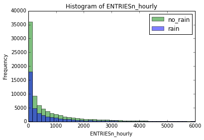

```python
'''
    Before we perform any analysis, it might be useful to take a
    look at the data we're hoping to analyze. More specifically, let's
    examine the hourly entries in our NYC subway data and determine what
    distribution the data follows. This data is stored in a dataframe
    called turnstile_weather under the ['ENTRIESn_hourly'] column.

    Let's plot two histograms on the same axes to show hourly
    entries when raining vs. when not raining. Here's an example on how
    to plot histograms with pandas and matplotlib:
    turnstile_weather['column_to_graph'].hist()

    Your histogram may look similar to bar graph in the instructor notes below.

    You can read a bit about using matplotlib and pandas to plot histograms here:
    http://pandas.pydata.org/pandas-docs/stable/visualization.html#histograms

    You can see the information contained within the turnstile weather data here:
    https://www.dropbox.com/s/meyki2wl9xfa7yk/turnstile_data_master_with_weather.csv
'''
%matplotlib inline
import numpy as np
import pandas
import matplotlib.pyplot as plt

def entries_histogram(filename):
    turnstile_weather=pandas.read_csv(filename)
    #print turnstile_weather
    #print 'Hallo'
    plt.figure()
    binBoundaries = np.linspace(0,6000,num=40)
    df_norain=turnstile_weather['ENTRIESn_hourly'][turnstile_weather['rain']==0]
    df_rain=turnstile_weather['ENTRIESn_hourly'][turnstile_weather['rain']==1]
    df_rain = df_rain.reset_index()
    df_norain = df_norain.reset_index()
    plt.hist(df_norain['ENTRIESn_hourly'],bins=binBoundaries,alpha=0.5, color='g')
    plt.hist(df_rain['ENTRIESn_hourly'], bins=binBoundaries,alpha=0.5, color='b')
    plt.legend(['no_rain','rain'])
    plt.xlabel('ENTRIESn_hourly')
    plt.ylabel('Frequency')
    plt.title('Histogram of ENTRIESn_hourly')
    plt.axis([0,6000,0,40000])
    #plt.savefig('test_1.png')
    plt.show()
    return plt

plot=entries_histogram('turnstile_data_master_with_weather.csv')
```

Problem-Set No.3 Analyzing Subway-Data: Exercise 2

The data in the chart above looks not normally distributed, so we can not apply a Welch-Test because it can only be used when the two populations are normal distributed (Literatur: https://en.wikipedia.org/wiki/Welch%27s_t_test, section "Assumption")

Problem-Set No.3 Analyzing Subway-Data: Exercise 3 Mann-Whitney_U-Test

```python
 '''
    This function will consume the turnstile_weather dataframe containing
    our final turnstile weather data.

    You will want to take the means and run the Mann Whitney U-test on the
    ENTRIESn_hourly column in the turnstile_weather dataframe.

    This function should return:
        1) the mean of entries with rain
        2) the mean of entries without rain
        3) the Mann-Whitney U-statistic and p-value comparing the number of entries
           with rain and the number of entries without rain

    You should feel free to use scipy's Mann-Whitney implementation, and you
    might also find it useful to use numpy's mean function.

    Here are the functions' documentation:
    http://docs.scipy.org/doc/scipy/reference/generated/scipy.stats.mannwhitneyu.html
    http://docs.scipy.org/doc/numpy/reference/generated/numpy.mean.html
'''
import numpy as np
import scipy
import scipy.stats
import pandas

def mann_whitney_plus_means(filename):
    turnstile_weather=pandas.read_csv(filename)
    with_rain_mean=np.mean(turnstile_weather['ENTRIESn_hourly'][turnstile_weather['rain']==1])
    #print with_rain_mean
    without_rain_mean=np.mean(turnstile_weather['ENTRIESn_hourly'][turnstile_weather['rain']==0])
    #print with_rain_mean
    U,p=scipy.stats.mannwhitneyu(turnstile_weather['ENTRIESn_hourly'][turnstile_weather['rain']==0],turnstile_weather['ENTRIESn_hourly'][turnstile_weather['rain']==1])
    p=2*p   ##For a two tailed test
    ### YOUR CODE HERE ###
    #print U
    #print p

    return with_rain_mean, without_rain_mean, U, p # leave this line for the grader
print 'with_rain_mean: %f'% (mann_whitney_plus_means("turnstile_data_master_with_weather.csv")[0])
print 'without_rain_mean: %f'% (mann_whitney_plus_means("turnstile_data_master_with_weather.csv")[1])
print 'U: %f'% (mann_whitney_plus_means("turnstile_data_master_with_weather.csv")[2])
print 'p-value: %f'% (mann_whitney_plus_means("turnstile_data_master_with_weather.csv")[3])
```

```
with_rain_mean: 1105.446377
without_rain_mean: 1090.278780
U: 1924409167.000000
p-value: 0.050000
```

Problem-Set No.3 Analyzing Subway-Data: Exercise 4

The distribution of the numbers of entries is statistically different between rainy and non rainy days. With a p-value (two tailed test) of 5 % which equals the 5% Alpha criteria of statistical significance.

Problem-Set No.3 Analyzing Subway-Data: Exercise 5 Linear Regression

```python
import numpy as np
import pandas
import statsmodels.api as sm
import math
import datetime as dt

"""
In this question, you need to:
1) implement the linear_regression() procedure
2) Select features (in the predictions procedure) and make predictions.

"""
def linear_regression(features, values):

    features=sm.add_constant(features)
    model=sm.OLS(values,features)
    result=model.fit()
    intercept=result.params[0]
    params=result.params[1:]
    #print params
    return intercept, params

def predictions(filename):
    '''
    The NYC turnstile data is stored in a pandas dataframe called weather_turnstile.
    Using the information stored in the dataframe, let's predict the ridership of
    the NYC subway using linear regression with gradient descent.

    You can download the complete turnstile weather dataframe here:
    https://www.dropbox.com/s/meyki2wl9xfa7yk/turnstile_data_master_with_weather.csv

    Your prediction should have a R^2 value of 0.40 or better.
    You need to experiment using various input features contained in the dataframe.
    We recommend that you don't use the EXITSn_hourly feature as an input to the
    linear model because we cannot use it as a predictor: we cannot use exits
    counts as a way to predict entry counts.

    Note: Due to the memory and CPU limitation of our Amazon EC2 instance, we will
    give you a random subet (~10%) of the data contained in
    turnstile_data_master_with_weather.csv. You are encouraged to experiment with
    this exercise on your own computer, locally. If you do, you may want to complete Exercise
    8 using gradient descent, or limit your number of features to 10 or so, since ordinary
    least squares can be very slow for a large number of features.

    If you receive a "server has encountered an error" message, that means you are
    hitting the 30-second limit that's placed on running your program. Try using a
    smaller number of features.
    '''
    dataframe=pandas.read_csv(filename)
    #########################################TEST-Calculations#############################
    a=[]
    b=[]
    #a[1]=1
    for i in range(0,len(dataframe['datetime'])):
        a.append(dataframe['datetime'][i].split(' ')[0])
        b.append(dataframe['datetime'][i].split(' ')[1])
    c=[]
    for i in range(0,len(a)):
        y=int(b[i].split(':')[0])
        #print b
        c.append(y)
    ######################################################################################
    dataframe['Minute']=np.asarray(c)
    #print dataframe
    features = dataframe[['fog','rain', 'precipi','tempi','hour','weekday','wspdi','latitude','longitude','day_week','Minute','pressurei']]
    dummy_units = pandas.get_dummies(dataframe['UNIT'], prefix='unit')
    features = features.join(dummy_units)
    features
    values = dataframe['ENTRIESn_hourly']

    # Perform linear regression
    intercept, params = linear_regression(features, values)
    #print params
    predictions = intercept + np.dot(features, params)

    #Calculating Coefficient of Determination
    #mean of values
    mean_values = np.mean(values)
    #print mean_values
    #print (values-predictions)**2
    #square= lambda x: math.pow(x,2)
    SS_res = np.sum((values-predictions)**2)
    #print SS_res
    SS_tot= np.sum((values-mean_values)**2)
    #print SS_tot
    R_2 = 1-SS_res/SS_tot
    #print 'Coefficient of Determination\nR^2:'
    #print R_2
    return predictions,R_2
r,R_2= predictions('turnstile_weather_v2.csv')
print 'Coefficient of Determination\nR^2:'
print R_2
```

```
Coefficient of Determination
R^2:
0.484260063709
```

Problem-Set No.3 Analyzing Subway-Data: Exercise 6 Plotting Residuals

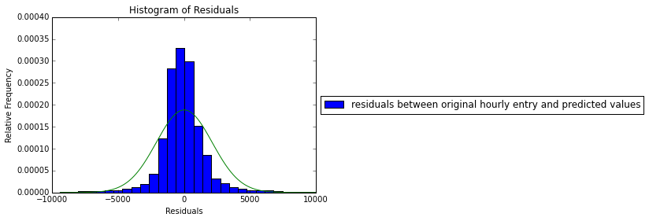

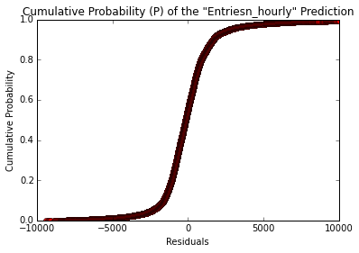

```python
%matplotlib inline
import numpy as np
import scipy.stats as stats
import matplotlib.pyplot as plt

def plot_residuals(turnstile_weather, predictions):
    '''
    Using the same methods that we used to plot a histogram of entries
    per hour for our data, why don't you make a histogram of the residuals
    (that is, the difference between the original hourly entry data and the predicted values).
    Try different binwidths for your histogram.

    Based on this residual histogram, do you have any insight into how our model
    performed?  Reading a bit on this webpage might be useful:

    http://www.itl.nist.gov/div898/handbook/pri/section2/pri24.htm
    '''

    plt.figure(1)
    residuals_0=turnstile_weather['ENTRIESn_hourly'] - predictions
    #print residuals
    residuals_1=sorted(residuals_0,key=float)
    #print len(residuals)
    probability=[]
    for i in range(0,len(residuals_1)):
        #print i
        b=i/(float(len(residuals_1)+1))
        #print b
        probability.append(b)
    #print probability
    plt.hist(turnstile_weather['ENTRIESn_hourly'] - predictions,bins=50,normed=True)
    plt.legend(['residuals between original hourly entry and predicted values'], loc = 'center left', bbox_to_anchor = (1.0, 0.5))
    plt.xlabel('Residuals')
    plt.ylabel('Relative Frequency')
    plt.title('Histogram of Residuals')
    fit = stats.norm.pdf(residuals_1, np.mean(residuals_1), np.std(residuals_1))
    plt.plot(residuals_1,fit,'-')
    plt.axis([-10000,10000,0,0.0004])

    ##Normal Probability Plot
    plt.figure(2)
    plt.plot(residuals_1,probability,'ro--')
    plt.xlabel('Residuals')
    plt.ylabel('Cumulative Probability ')
    plt.title('Cumulative Probability (P) of the "Entriesn_hourly" Prediction')
    plt.axis([-10000,10000,0,1])
    plt.show()


turnstile_weather=pandas.read_csv('turnstile_weather_v2.csv')
result=plot_residuals(turnstile_weather,predictions('turnstile_weather_v2.csv')[0])
```

Based on this residual histogram, do you have any insight into how our model performed? Reading a bit on this webpage might be useful:

Our Regression seems to be good. In the residual area [-2000;2000] where most of our values are the probability (p) follows a shape of a straight line.

Problem-Set No.3 Analyzing Subway-Data: Exercise 7 Compute R^2

```python
import numpy as np
import scipy
import matplotlib.pyplot as plt
import sys
import pandas
def compute_r_squared(data, predictions):
    '''
    In exercise 5, we calculated the R^2 value for you. But why don't you try and
    and calculate the R^2 value yourself.

    Given a list of original data points, and also a list of predicted data points,
    write a function that will compute and return the coefficient of determination (R^2)
    for this data.  numpy.mean() and numpy.sum() might both be useful here, but
    not necessary.

    Documentation about numpy.mean() and numpy.sum() below:
    http://docs.scipy.org/doc/numpy/reference/generated/numpy.mean.html
    http://docs.scipy.org/doc/numpy/reference/generated/numpy.sum.html
    '''

    ss_prediction=np.sum(np.square(data-predictions))
    mean=np.mean(data)
    ss_tot=np.sum(np.square(data-mean))
    r_squared=1-ss_prediction/ss_tot
    return r_squared
dataframe=pandas.read_csv('turnstile_weather_v2.csv')
data=dataframe['ENTRIESn_hourly']
prediction,R_2= predictions('turnstile_weather_v2.csv')

compute_r_squared(data,prediction)
```

```
0.4842600637093988
```

Problem-Set No.3 Analyzing Subway-Data: Exercise 8 Compute Gradient Descent

```python
import numpy as np
import pandas
from sklearn.linear_model import SGDRegressor

"""
In this question, you need to:
1) Implement the linear_regression() procedure using gradient descent.
   You can use the SGDRegressor class from sklearn, since this class uses gradient descent.
2) Select features (in the predictions procedure) and make predictions.

"""
def normalize_features(features):
    '''
    Returns the means and standard deviations of the given features, along with a normalized feature
    matrix.
    '''
    means = np.mean(features, axis=0)
    std_devs = np.std(features, axis=0)
    normalized_features = (features - means) / std_devs
    return means, std_devs, normalized_features

######################################################################################################

def recover_params(means, std_devs, norm_intercept, norm_params):
    '''
    Recovers the weights for a linear model given parameters that were fitted using
    normalized features. Takes the means and standard deviations of the original
    features, along with the intercept and parameters computed using the normalized
    features, and returns the intercept and parameters that correspond to the original
    features.
    '''
    intercept = norm_intercept - np.sum(means * norm_params / std_devs)
    params = norm_params / std_devs
    #print params
    return intercept, params

def linear_regression(features, values):
    """
    Perform linear regression given a data set with an arbitrary number of features.
    """
    regression=SGDRegressor()
    result=regression.fit(features,values)
    intercept=result.intercept_
    params=result.coef_

    return intercept, params

def predictions_Gradient_Acent(dataframe):
    '''
    The NYC turnstile data is stored in a pandas dataframe called weather_turnstile.
    Using the information stored in the dataframe, let's predict the ridership of
    the NYC subway using linear regression with gradient descent.

    You can download the complete turnstile weather dataframe here:
    https://www.dropbox.com/s/meyki2wl9xfa7yk/turnstile_data_master_with_weather.csv

    Your prediction should have a R^2 value of 0.40 or better.
    You need to experiment using various input features contained in the dataframe.
    We recommend that you don't use the EXITSn_hourly feature as an input to the
    linear model because we cannot use it as a predictor: we cannot use exits
    counts as a way to predict entry counts.

    Note: Due to the memory and CPU limitation of our Amazon EC2 instance, we will
    give you a random subset (~50%) of the data contained in
    turnstile_data_master_with_weather.csv. You are encouraged to experiment with
    this exercise on your own computer, locally.

    If you receive a "server has encountered an error" message, that means you are
    hitting the 30-second limit that's placed on running your program. Try using a
    smaller number of features or fewer iterations.
    '''
    ################################ MODIFY THIS SECTION #####################################
    # Select features. You should modify this section to try different features!             #
    # We've selected rain, precipi, Hour, meantempi, and UNIT (as a dummy) to start you off. #
    # See this page for more info about dummy variables:                                     #
    # http://pandas.pydata.org/pandas-docs/stable/generated/pandas.get_dummies.html          #
    ########################################################]##################################
    features = dataframe[['rain','precipi', 'hour','fog','weekday','wspdi']]
    dummy_units = pandas.get_dummies(dataframe['UNIT'], prefix='unit')
    features = features.join(dummy_units)

    # Values
    values = dataframe['ENTRIESn_hourly']

    # Get numpy arrays
    features_array = features.values
    values_array = values.values

    means, std_devs, normalized_features_array = normalize_features(features_array)

    # Perform gradient descent
    norm_intercept, norm_params = linear_regression(normalized_features_array, values_array)

    intercept, params = recover_params(means, std_devs, norm_intercept, norm_params)
    print params[0:6]
    #print params[2]
    predictions = intercept + np.dot(features_array, params)
    # The following line would be equivalent:
    # predictions = norm_intercept + np.dot(normalized_features_array, norm_params)
    R_2=compute_r_squared(values,predictions)
    return predictions,R_2

#####Execution of the functions##########################################
dataframe=pandas.read_csv('turnstile_weather_v2.csv')
predictions_gradient_acent,R_2=predictions_Gradient_Acent(dataframe)
print 'Coefficient of Determination:\n R^2= %f'%(R_2)
```

```
[  123.86170053 -4538.92280562   128.13197714  -767.07272957   984.706002
    12.00287892]
Coefficient of Determination:
 R^2= 0.464876
```

# Problem-Set 4 Visualizing Subway Data

Problem-Set No.4 Visualizing Subway Data: Excercise 1 Visualization 1

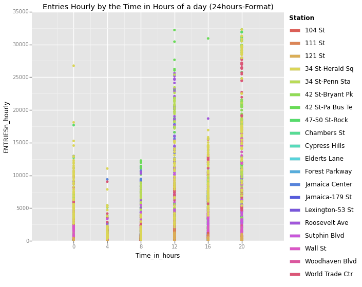

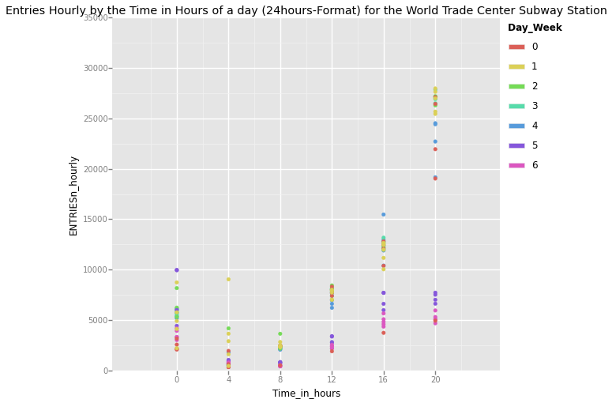

```python
%matplotlib inline
from pandas import *
from ggplot import *
import re
import datetime
import matplotlib.pyplot as plt
import numpy as np


def plot_weather_data(turnstile_weather):
    '''
    You are passed in a dataframe called turnstile_weather.
    Use turnstile_weather along with ggplot to make a data visualization
    focused on the MTA and weather data we used in assignment #3.
    You should feel free to implement something that we discussed in class
    (e.g., scatterplots, line plots, or histograms) or attempt to implement
    something more advanced if you'd like.

    Here are some suggestions for things to investigate and illustrate:
     * Ridership by time of day or day of week
     * How ridership varies based on Subway station (UNIT)
     * Which stations have more exits or entries at different times of day
       (You can use UNIT as a proxy for subway station.)

    If you'd like to learn more about ggplot and its capabilities, take
    a look at the documentation at:
    https://pypi.python.org/pypi/ggplot/

    You can check out:
    https://www.dropbox.com/s/meyki2wl9xfa7yk/turnstile_data_master_with_weather.csv

    To see all the columns and data points included in the turnstile_weather
    dataframe.

    However, due to the limitation of our Amazon EC2 server, we are giving you a random
    subset, about 1/3 of the actual data in the turnstile_weather dataframe.
    '''
    dataframe.is_copy = False
    part=dataframe['UNIT'][0]
    part_2= re.split('(\d.*)',part)
    #Calculate a Decimal value for the time
    dataframe['Time_in_hours']=""
    #print  dataframe['Time in hours']
    for i in range(0,len(dataframe['Time_in_hours'])):
        [hours, minutes, seconds] = [int(x) for x in dataframe['TIMEn'][i].split(':')]
        x = datetime.timedelta(hours=hours, minutes=minutes, seconds=seconds)
        dataframe['Time_in_hours'][i]=x.seconds/3600
        #print hour
    length_data=int(len(dataframe['TIMEn'])*0.1)
    dataframe_short=dataframe[:length_data]
    dataframe_world_trade_subway=dataframe[dataframe['station']=='WORLD TRADE CTR']
    #print dataframe_world_trade_subway['station']
    plot1 = ggplot(dataframe_short,aes('Time_in_hours','ENTRIESn_hourly',colour='station'))+geom_point()+\
                ggtitle('Entries Hourly by the Time in Hours of a day (24hours-Format)')+ylim(0,35000)+ scale_x_continuous(breaks=[0,4,8,12,16,20])
##I just used 10% of the whole data, because otherwise the graph is overloaded with data and subway stations
##################################################################################################
##################################################################################################
    #plot for only one station subway: World Trade Ctr
    plot2 = ggplot(dataframe_world_trade_subway,aes('Time_in_hours','ENTRIESn_hourly',colour='day_week'))+geom_point()+\
                ggtitle('Entries Hourly by the Time in Hours of a day (24hours-Format) for the World Trade Center Subway Station')+scale_x_continuous(breaks=[0,4,8,12,16,20])+ylim(0,35000)
    print plot1
    print plot2
##################################################################################################
##################################################################################################

############## Problem-Set No.4 Visualizing Subway Data: Excercise 2 Visualization 2#####################
    ''' You should make a type of visualization that is different than what you did in exercise #1.
    Try to use the data in a different way (e.g., if you made a lineplot concerning ridership
    and time of day in exercise #1, maybe look at weather and try to make a histogram in exercise #2).
    Or attemp to use multiple encodings in your graph if you haven't in the previous exercise.
    '''
#Histogram for the World Trade Center Subway Station for different times of the day and weather conditions
    #p = ggplot(aes(x='a'), data=df)
    #p + geom_histogram(binwidth=1)
    #binBoundaries = np.linspace(0,6000,num=40)
    bins=np.linspace(0,30000,num=100)
    #print bins
    plt.figure(1)
    '''
    df_1=dataframe_world_trade_subway[dataframe_world_trade_subway['Time_in_hours']==12]
    df_2=dataframe_world_trade_subway[dataframe_world_trade_subway['Time_in_hours']==16]
    df_3=dataframe_world_trade_subway[dataframe_world_trade_subway['Time_in_hours']==20]
    plt.hist(df_1['ENTRIESn_hourly'],bins,alpha=0.5, color='g')
    plt.hist(df_2['ENTRIESn_hourly'],bins,alpha=0.5, color='b')
    plt.hist(df_3['ENTRIESn_hourly'],bins,alpha=0.5, color='r')
    plt.legend(['Time:12:00','Time:16:00','Time:20:00'],bbox_to_anchor=(1, 0.5),loc='center left')
    plt.xlabel('ENTRIESn_hourly')
    plt.ylabel('Frequency')
    plt.title('Histogram of ENTRIESn_hourly at the World Trade Center Subway Station')
    plt.show()
    '''
##############################
    '''
    plt.figure(2)

    dataframe_world_trade_subway_rain=dataframe_world_trade_subway[dataframe_world_trade_subway['rain']==1]

    dataframe_world_trade_subway_norain=dataframe_world_trade_subway[dataframe_world_trade_subway['rain']==0]

    df_4=dataframe_world_trade_subway_rain[dataframe_world_trade_subway_rain['Time_in_hours']==20]
    df_5=dataframe_world_trade_subway_norain[dataframe_world_trade_subway_norain['Time_in_hours']==20]
    df_6=dataframe_world_trade_subway_rain[dataframe_world_trade_subway_rain['Time_in_hours']==16]
    df_7=dataframe_world_trade_subway_norain[dataframe_world_trade_subway_norain['Time_in_hours']==16]

    plt.hist(df_4['ENTRIESn_hourly'],bins,alpha=0.5, color='g')
    plt.hist(df_5['ENTRIESn_hourly'],bins,alpha=0.5, color='b')
    plt.hist(df_6['ENTRIESn_hourly'],bins,alpha=0.5, color='y')
    plt.hist(df_7['ENTRIESn_hourly'],bins,alpha=0.5, color='r')
    plt.legend(['Time:20:00+rain','Time:20:00+Norain','Time:16:00+rain','Time:16:00+Norain'],bbox_to_anchor=(1, 0.5),loc='center left')
    plt.xlabel('ENTRIESn_hourly')
    plt.ylabel('Frequency')
    plt.title('Histogram of ENTRIESn_hourly at the World Trade Center Subway Station depending on Time and Rain')
    plt.show()
    '''






    return plot1,plot2
dataframe_for_ggplot=pandas.read_csv('turnstile_weather_v2.csv')
result=plot_weather_data(dataframe_for_ggplot)
```